# Creating Towers

What would a tower defense be without towers? Let’s build the protagonists of this genre: *Towers*.

In this lesson you’ll learn to:

- Detect input inside an area
- Select objects
- Display and hide GUI elements in runtime

The tower uses the *Weapon2D* we’ve made in the previous lesson. It also has an area that detects mouse clicks and toggles its selection. When selected, the tower displays an interface that allows players to sell it.

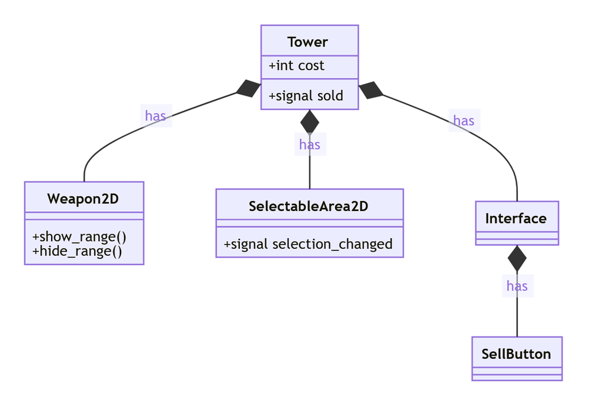

We’ll start by assembling the tower and attaching a weapon to it. Then, we’ll create a selection area around the tower to detect when players click on it. We’ll also create the interface that appears once players select the tower. We’ll connect everything in the tower’s script.

## Structuring the Scene

Since a tower is a concrete object in the game’s world, it has a position, rotation, and scale. The root of our tower scene is a *Node2D*. Rename it *Tower*. Save it as `res://Objects/Towers/Tower.tscn`.

For the graphics, we use two *Sprites*. Name them *BaseSprite* and *GlassSprite*. You can find the sprite sheet image in the `res://sprite-sheet.svg` file. Drag it to each *Texture* slot and toggle the *Region Enabled* flag.

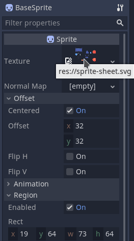

For the *BaseSprite*, select the region that represents the base of the tower in the *TextureRegion* dock.

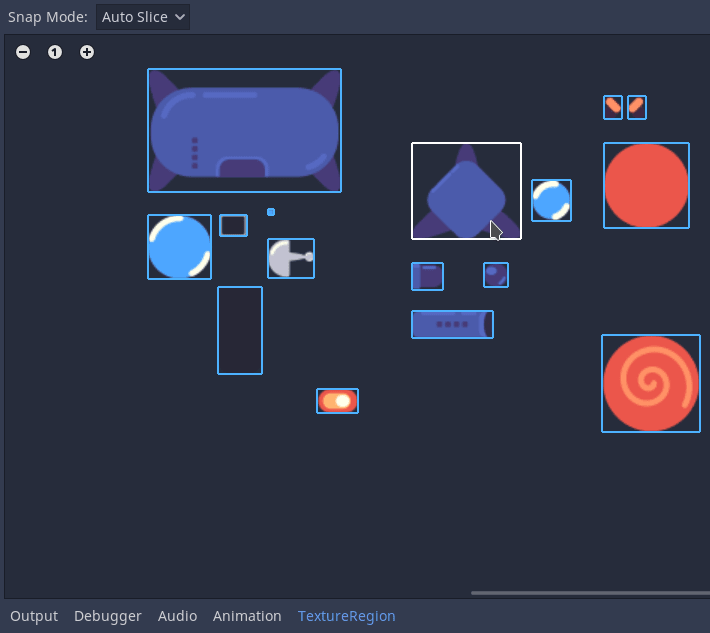

For the *GlassSprite*, select the texture isle that looks like a small glass ball. Position it to so it looks something like this.

[figure not shown]

Now, let’s add an instance of the *Weapon2D* as a *Tower*’s child. The *Godot Engine* processes the `SceneTree` from top to bottom. This means that Godot draws *CanvasItems* from top to bottom. Also be sure align the weapon with to the tower’s sprite.

To correctly draw our *Tower*, move the *Weapon2D* between the *BaseSprite* and the *GlassSprite*. Like a sandwich.

[figure not shown]

## Selecting towers

When the *Towers* are in the game world, players should be able to interact with them. To detect which tower the players is interacting with, we need a selection mechanism so we can sell towers for example.

To allow players to select a *Tower*, we can use *Area2Ds*’s `_input_event` virtual method. This method processes inputs that happen inside the *Area2D*.

Add an *Area2D* to the *Tower*’s hierarchy and rename it *SelectableArea2D*. Save it as a scene by right-clicking it and selecting *Save Branch as Scene*. We can focus on its behavior and have a reusable node available if it’s its own scene. You can save it as `res://Objects/SelectableArea2D/SelectableArea2D.tscn`.

Open the newly created scene and attach a script to it. Save it in the same folder as the scene.

A *SelectableArea2D* is responsible to communicate when players select an object. It communicates that via a signal that notifies about its selection state.

We also need to know what input the *SelectableArea2D* is listening to. In our project, we have an action called *select* in the `InputMap`. But to make this node reusable across projects, let’s export `select_action`. This will allow us to change it through the *Inspector*.

Then, to keep track of the current selection state we can create a boolean variable called `selected`.

In the setter method for `selected`, we add or remove this *SelectableArea2D* from a group called *selected* based on its selection state. After that we emit its `selection_changed` signal notifying its current selection state.

```
# Communicates selection states at individual level.
class_name SelectableArea2D
extends Area2D

signal selection_changed(selected)

# The InputAction's name used to detect when a left mouse click happens inside
# the *SelectableArea2D*
export var select_action := "select"

var selected := false setget set_selected

func set_selected(select: bool) -> void:
    selected = select
    if selected:
        add_to_group("selected")
    else:
        remove_from_group("selected")
    emit_signal("selection_changed", selected)
```

Now let’s use the `_input_event()` method to detect when players click on the *SelectableArea2D*. To toggle the `selected` state we can set it to be the invert of its current value using the keyword `not`.

```
func _input_event(_viewport: Object, event: InputEvent, _shape_idx: int) -> void:
    if event.is_action_pressed(select_action):
        set_selected(not selected)
```

We’ve decided that it should deselect when players click outside the *SelectableArea2D*. But until now, we only listen to inputs that happen inside the *SelectableArea2D*.

We can use the `_unhandled_input` callback… with a twist! We need to turn it off in the `_ready()` callback because it should only process when the mouse is outside the *SelectableArea2D*. This prevents it from detecting inputs even when the player never selects the *Tower*.

```
func _ready() -> void:
    set_process_unhandled_input(false)
```

To know when the mouse enters or leaves an *Area2D* we can use their `mouse_entered` and `mouse_exited` signals. Connect these signals on the *SelectableArea2D*’s `_on_mouse_entered` and `_on_mouse_exited` signal callbacks.

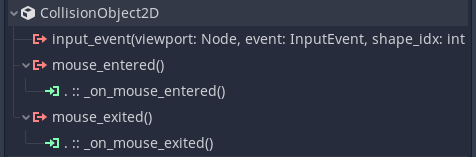

When the mouse enters the *SelectableArea2D*, we don’t need the `_unhandled_input()` to process. This is because we use the `_input_event()` instead. Turn it off inside the `_on_mouse_entered()` callback.

When the mouse exits, we enable the `_unhandled_input` only if the *SelectableArea2D* is selected. If for any reasons the `_unhandled_input` is processing, we should disable it. For that, we can call the `set_process_unhandled_input()` passing `selected` as argument. This will take the current value of the `selected` variable. If it’s selected, it can process unhandled inputs. Otherwise, it doesn’t.

```
func _on_mouse_entered() -> void:
    set_process_unhandled_input(false)


func _on_mouse_exited() -> void:
    set_process_unhandled_input(selected)
```

In the `_unhandled_input`, we check if the player pressed the `select_action`. This action represents events from the left mouse button. If players clicked, we set the `selected` value to `false`. To prevent it from processing, we disable the `_unhandled_input` processing after that.

```
func _unhandled_input(event: InputEvent) -> void:
    if event.is_action_pressed(select_action):
        set_selected(false)
        set_process_unhandled_input(false)
```

### Code so far

Here is the final version of our *SelectableArea2D* script.

```
# Communicates selection states at individual level.
class_name SelectableArea2D
extends Area2D

signal selection_changed(selected)

export var select_action := "select"

var selected := false setget set_selected


func _ready() -> void:
    set_process_unhandled_input(false)


func _input_event(_viewport: Object, event: InputEvent, _shape_idx: int) -> void:
    if event.is_action_pressed(select_action):
        set_selected(not selected)


func _unhandled_input(event: InputEvent) -> void:
    if event.is_action_pressed(select_action):
        set_selected(false)
        set_process_unhandled_input(false)


func set_selected(select: bool) -> void:
    selected = select
    if selected:
        add_to_group("selected")
    else:
        remove_from_group("selected")
    emit_signal("selection_changed", selected)


func _on_mouse_entered() -> void:
    set_process_unhandled_input(false)


func _on_mouse_exited() -> void:
    set_process_unhandled_input(selected)
```

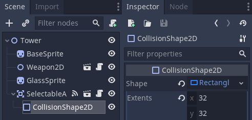

Then move the *SelectableArea2D* to the center of the *Tower*’s sprites. It’s position should be `32` on both `x` and `y` axes.

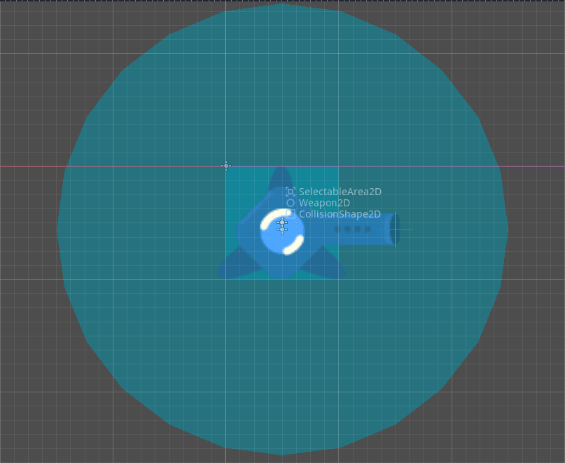

## Displaying the interface

In the *Godot Engine*, we use *Control* nodes to design user interfaces. Usually, we stack *Controls* in a *Control* only hierarchy but we can also attach *Controls* directly to in-game objects. This allows the *Node2D*’s transform, such as its position, to affect the *Control*.

In the `res://UI/UIUnit/` folder, we have an *UIUnit* scene made up which displays information about the tower.

The *UIUnit* appears and disappears using animations. This is more pleasing visually than turning its visibility on or off.

Attach an instance of the *UIUnit* scene as a child of the root node. Note that the name of the scene is *Interface* to make it clear what its function is.

[figure not shown]

When players select the tower, the *Interface* should pop on the screen quickly. During the animation, we overshoot the *Interface > Rect Scale* using the *EASE OUT* interpolation.

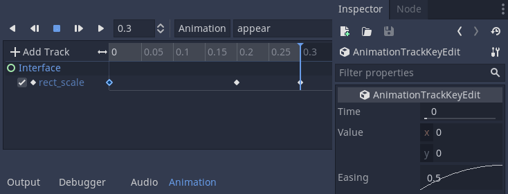

We do something similar for the *disappear* animation. To create a feeling of anticipation, we scale it up a bit before scaling it down to `0:0`. We also use the *EASE OUT* interpolation here.

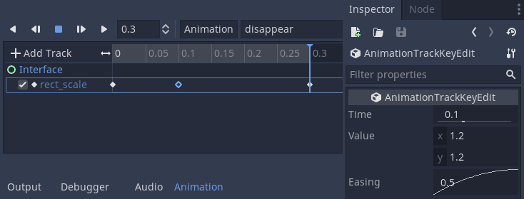

Having the *UIUnit* saved as a separate scene allows us to reuse it across the project. For instance, it will be useful when we design the player base to show its health.

It also stops direct access to the *AnimationPlayer*. Instead, other classes use its methods found to make it appear or disappear.

`UIUnit.gd`

```
extends Control


onready var _anim_player := $AnimationPlayer

func appear() -> void:
    _anim_player.play("appear")


func disappear() -> void:
    _anim_player.play("disappear")
```

Back to the *Tower* scene, add a *Button* as child of the *Interface*. It will allow players to sell the *Tower*. Rename it as *SellButton*.

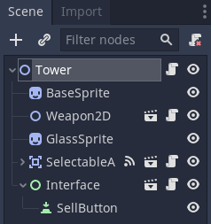

*Change* the *SellButton > Text* to *Sell* to communicate to players what this button does.

*Note* that the *SellButton* already has a theme different from the default. This is because we’ve set a custom theme in the *Project > Project Settings > GUI > Theme* settings.

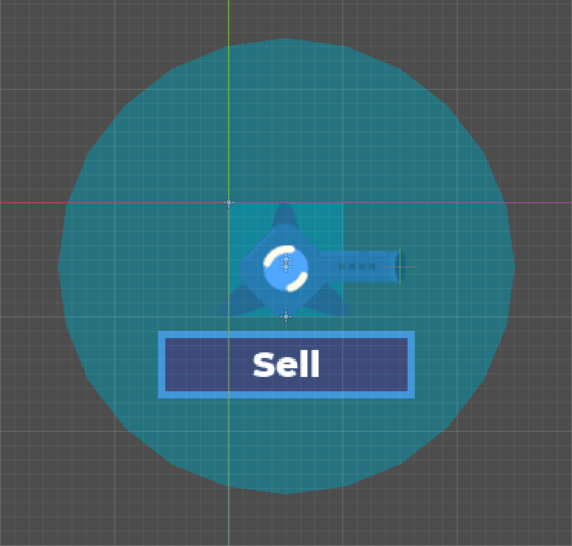

*If the button isn’t appearing, make sure the Interface > Rect Scale is 1 in both axes.*

To finish up with the interface, we display the weapon’s cooldown in the form of a progress bar. For that we have the *UICooldownBar* which you can find at `res://UI/UICooldownBar/UICooldownBar.tscn`. Attach one as a child of the root node. We always want it displayed for the player so they know when the weapon will fire.

The *UICooldownBar* has a progress bar, a timer, and some textures to represent a clock. It uses a gradient to tint the bar based on the time remaining to cooldown.

We’ll connect it in the next section.

[figure not shown]

## Scripting the tower’s behavior

With everything now in place, it’s time to code the tower’s behavior. Attach a new script to the *Tower* and save both the script and the scene in `res://Objects/Towers/`.

Players can buy *Towers* through a shop by paying a given price for them. We represent this price through a `cost` variable. *Towers* should notify other objects if the player has sold them. With this notification, we should send over:

- The cost given back to the player
- The position of the *Tower*

We create a signal with these two arguments.

Let’s also create a signal to notify other classes that the player has selected the tower. This will allow us to use connect interface elements to it later when we display information in the user interface.

```
class_name Tower
extends Node2D

signal sold(price, place)
signal selected(selected)

export var cost := 100
```

Let’s store references to important nodes.

```
onready var _weapon := $Weapon2D
onready var _interface := $Interface
onready var _cooldown_bar := $UICooldownBar
onready var _selection := $SelectableArea2D
```

A *Tower* should show its fire range the first time it appears on the screen so players can place towers more strategically.

```
func _ready() -> void:
    _weapon.show_range()
```

*Towers* toggle their *Interface*’s visibility when a player selects them, so we create methods to show and hide interface elements.

```
func show_interface() -> void:
    _weapon.show_range()
    _interface.appear()


func hide_interface() -> void:
    _weapon.hide_range()
    _interface.disappear()
```

To know when players select the tower, we connect the *SelectableArea2D*’s `selection_changed` signal in the *Tower*’s `_on_SelectableArea2D_selection_changed()` callback. We can use the `selected` argument passed through the signal to know if a player has selected this tower.

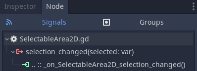

We define what happens when the player selects a *Tower* in this method. We call the `show_interface()` method if `selected` is `true`. Otherwise, we call the `hide_interface()` method. We also emit the `selected` signal to forward the `selected` value.

```
func _on_SelectableArea2D_selection_changed(selected) -> void:
    if selected:
        show_interface()
    else:
        hide_interface()
    emit_signal("selected", selected)
```

We’ve dealt with getting information about the *Tower*’s fire range, now let’s allow players to sell the *Tower*.

Connect the *SellButton*’s `pressed` signal to the *Tower*’s `_on_SellButton_pressed()` signal callback.

When players press the *SellButton*, the *Tower* emits its `sold` signal. It passes its sell price and current `position` as arguments. Here we’ve decided that the amount refunded is half the tower’s cost.

After emitting its sold notification, we can remove the *Tower* from the game by calling the `queue_free()` method.

```
func _on_SellButton_pressed() -> void:
    emit_signal("sold", cost / 2, position)
    queue_free()
```

When the weapon shoots, it needs to cool down before shooting again. We display this information using the *UICooldownBar*.

We start it using the `start()` method which asks for the `time` in seconds to cooldown.

To trigger the cooldown bar, let’s use the *Editor*’s interface to connect the *Weapon2D*’s `fired` signal to the tower and create a `_on_Weapon2D_fired()` callback.

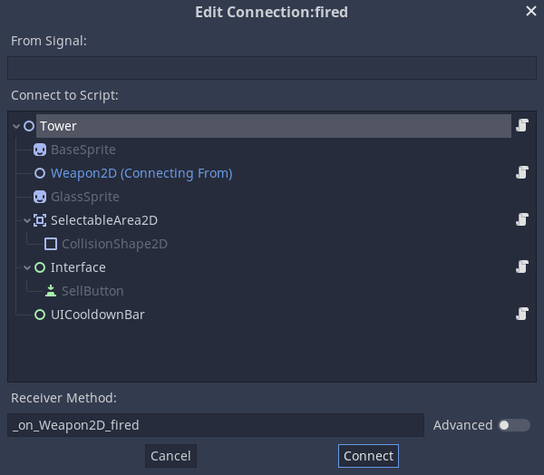

In this callback, we call the `_cooldown_bar.start()` method passing the `_weapon.fire_cooldown` as an argument.

```
func _on_Weapon2D_fired() -> void:
    _cooldown_bar.start(_weapon.fire_cooldown)
```

### Code so far

With that we’ve finished the *Tower* behavior.

`Tower.gd`

[output not shown]

## Testing the *Tower*

We have the *Tower* ready! It should show its interface elements, notify and disappear if we decide to sell it.

Move the *Tower* to the center of the scene and hit the *Test Scene* button. You can also press F6 instead.

You may notice that although it starts unselected, it shows its range. Once selected we can click on the *SellButton* to sell it. Doing so will make it disappear.

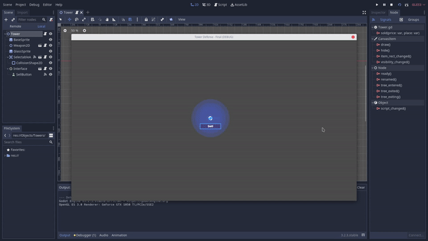